# Expert knowledge integration in species distribution model (SDM): A Bayesian approach

Camila Diaz

2026-06-23

# Overview

This document implements a two step Bayesian species distribution model (SDM) for monarch butterfly (*Danaus plexippus*) in Canada.

**Step 1: Expert knowledge model (Stan).** Expert elicited range limits and point observations are used to define an expert informed prior and a small occurrence dataset. Two Stan variants are compared: a baseline logistic model and a weighted likelihood model that down weights low confidence points. The posterior distributions of the regression coefficients are then extracted.

**Step 2: Model update with occurrence data (INLA).** The Stan posteriors are propagated as Gaussian priors into an R-INLA binomial model that includes a spatial random effect (SPDE/Matérn). The workflow is also run with non informative priors to provide a baseline comparison.

# 1. Setup

```r
library(dplyr)
library(ggplot2)
library(tidyr)
library(sf)
library(INLA)
library(geodata)
library(terra)
```

# 2. Data loading

```r
epsg <- 6622
epsg_crs <- "EPSG:6622"

map_crs <- 4326
map_epsg <- "EPSG:4326"
# Study area
study_area0 <- st_read("C:/Users/maria/Documents/GitHub/Expert_SDM/data/study_area/canada.shp",
  quiet = TRUE)

study_area <- study_area0 |>
  st_transform(epsg) |>
  st_union()|>
  st_simplify(dTolerance = 1000)|> # 1 km tolerance
  st_make_valid()

# Occurrence data
monarch_data <- st_read("C:/Users/maria/Documents/GitHub/Expert_SDM/data/species/PA_monarch_CAN.shp",
  quiet = TRUE)

monarch_sf <- monarch_data |>
  st_transform(crs = epsg)

# Expert knowledge data
ek_pnt <- read.csv("C:/Users/maria/Documents/GitHub/Expert_SDM/data/expert_knowledge/Points.csv")
ek_answrs <- read.csv("C:/Users/maria/Documents/GitHub/Expert_SDM/data/expert_knowledge/Responses.csv")

# Environmental layers - Ouranos
tas_mean0 <- rast("C:/Users/maria/Documents/GitHub/Expert_SDM/data/predictors/tas_mean.tif")
pr_mean0 <- rast("C:/Users/maria/Documents/GitHub/Expert_SDM/data/predictors/pr_mean.tif")
```

Four data sources are loaded:

[output not shown]

# 3. Environmental layer preparation

```r
tas_mean <- project(tas_mean0, epsg_crs)
tas_mask <- mask(tas_mean, vect(study_area))
mt <- global(tas_mask, mean, na.rm = TRUE)[1,1]
st <- global(tas_mask, sd, na.rm = TRUE)[1,1]
std_tas <- (tas_mask - mt) / st


pr_mean <- project(pr_mean0, epsg_crs)
pr_mask <- mask(pr_mean, vect(study_area))
mp <- global(pr_mask, mean, na.rm = TRUE)[1,1]
sp <- global(pr_mask, sd, na.rm = TRUE)[1,1]
std_pr <- (pr_mask - mp) / sp


env <- c(std_tas, std_pr)
names(env) <- c("temp", "prec")

env_df <- as.data.frame(env, xy = TRUE, na.rm = FALSE)

# Track which cells are non NA
valid_idx <- complete.cases(env_df[, c("temp", "prec")])
env_valid <- env_df[valid_idx, ]
```

$$z_i = \frac{x_i -
\bar{x}}{s_x}$$

where $\bar{x}$ and $s_x$ are the mean and standard deviation. This places both covariates on a common scale when they enter the model. The vectors `mt`, `st`, `mp`, `sp` are saved and reused in later to standardize the expert responses with the same transformation.

`valid_idx` flags the raster cells with non missing values for both covariates and is later used to fill prediction rasters from a flat prediction vector.

# 4. Step1: Expert knowledge processing

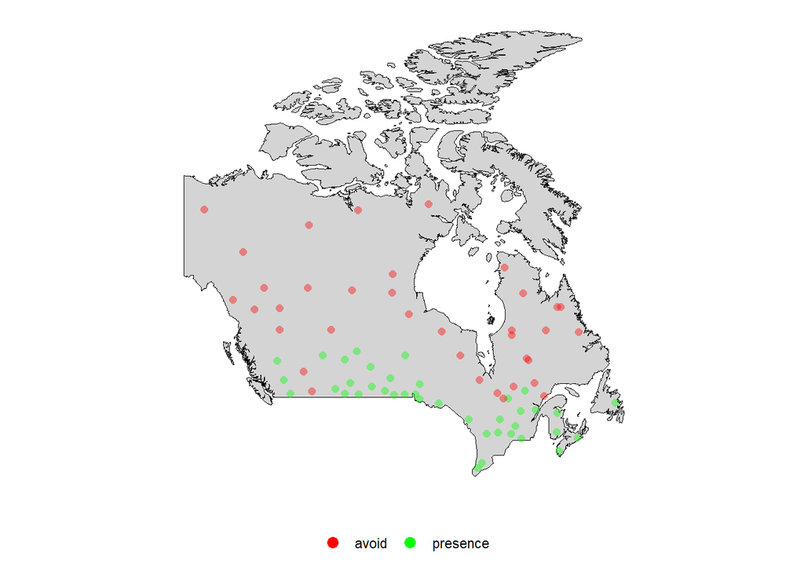

```r
# Spatialize expert points
sf_pnt <- ek_pnt |>
  st_as_sf(coords = c("long", "lat"),
           crs = 4326) |>
  st_intersection(study_area0) |>
  st_transform(crs = epsg)


sf_pnt <- sf_pnt |>
  mutate(y = as.integer(type == "presence"),
         temp = terra::extract(env$temp, vect(sf_pnt))[,2],
         prec = terra::extract(env$prec, vect(sf_pnt))[,2])

# --- Map point-level confidence to model quantities ---
# Weighted likelihood option: w = fractional weight of each observation.
#   High confidence -> full weight; Low -> quarter weight.
conf_weights   <- c(Low = 0.25, Medium = 0.50, High = 1.00)

sf_pnt <- sf_pnt |>
  mutate(
    w    = conf_weights[confidence]
  )

sf_pnt_prj <- st_transform(sf_pnt, map_crs)
m <- ggplot() +
  geom_sf(data = study_area0, fill = "grey83", color = "black") +
  geom_sf(data = sf_pnt_prj, aes(colour = type), alpha = 0.4, size = 2, shape = 16) +
  scale_colour_manual(
    name   = NULL,
    values = c("avoid"  = "red",
               "presence" = "green"),
    guide  = guide_legend(override.aes = list(size = 3, alpha = 1))
  ) +
  theme_minimal() +
  theme(
    legend.position   = "bottom",
    axis.text         = element_blank(),
    panel.grid        = element_blank()
  )
m
```

```r
# standardize range values and Keep the necessary columns
answrs_select <- ek_answrs |>
  mutate(std_min_temp = (min.temp - mt) / st,
         std_max_temp = (max.temp - mt) / st,
         std_min_prec = (min.prec - mp) / sp,
         std_max_prec = (max.prec - mp) / sp) |>
  select("survey_id", "std_min_temp", "std_max_temp", "confidence.temp", "std_min_prec", "std_max_prec", "confidence.prec")
```

**Expert points** (`sf_pnt`). The raw CSV coordinates are converted to an `sf` object, clipped to the study area, then reprojected. The binary response is defined as $y_n = 1$ if the label is `"presence"` and $y_n = 0$ otherwise. Standardized temperature and precipitation values are extracted at each point from the `env` stack.

**Confidence = model quantities.** Each point carries a self assessed confidence level (`Low`, `Medium`, `High`). This is mapped in the Weighted likelihood model:

| Confidence | `w` |
| --- | --- |
| Low | 0.25 |
| Medium | 0.50 |
| High | 1.00 |

`w` feeds the weighted likelihood model.

**Expert range responses:** The elicited minimum and maximum values for temperature and precipitation are standardized with the same $\bar{x}$ and $s_x$ used for the rasters, so they are directly comparable to the standardized covariate values. These become the prior centres $a_k^*$, $b_k^*$, $c_k^*$ for the triangular response function.

# 5. Stan data preparation

Using Stan to run step 1, expert informed model

```r
library(posterior)
library(rstan)

rstan_options(auto_write = TRUE)

sigma_levels <- c(Low = 0.01, Medium = 0.5, High = 1.0)

# Base data shared by all Stan models
stan_data_base <- list(
  N  = length(sf_pnt$y),
  y  = as.integer(sf_pnt$y),
  x1 = sf_pnt$temp,
  x2 = sf_pnt$prec,

   # Covariate 1 expert values + uncertainty
  a1_star = answrs_select$std_min_temp,
  b1_star = answrs_select$std_max_temp,
  c1_star = (answrs_select$std_max_temp/2),
  sigma_a1 = sigma_levels[answrs_select$confidence.temp],
  sigma_b1 = sigma_levels[answrs_select$confidence.temp],
  sigma_c1 = sigma_levels[answrs_select$confidence.temp],

  # Covariate 2 expert values + uncertainty
  a2_star = answrs_select$std_min_prec,
  b2_star = answrs_select$std_max_prec,
  c2_star = (answrs_select$std_max_prec/2),
  sigma_a2 = sigma_levels[answrs_select$confidence.prec],
  sigma_b2 = sigma_levels[answrs_select$confidence.prec],
  sigma_c2 = sigma_levels[answrs_select$confidence.prec],

  # Slope priors (both positive effects expected)
  beta1_mu = 1,
  beta1_sigma = sigma_levels[answrs_select$confidence.temp],
  beta2_mu = 1,
  beta2_sigma = sigma_levels[answrs_select$confidence.prec]
)

# Original model (baseline)
stan_data <- stan_data_base

# weighted likelihood model (weight per point)
stan_data_weighted <- c(
  stan_data_base,
  list(w = sf_pnt$w)
)
```

```r
stan_code <- stan_model(
  file = "Step1-Expert_model.stan",
  verbose = FALSE)

fit <- sampling(stan_code,
                data = stan_data,
                chains = 4,
                refresh = 0,
                show_messages = FALSE,
                open_progress = FALSE)

print(fit, pars = c("beta1", "beta2"))
```

```
#> Inference for Stan model: anon_model.
#> 4 chains, each with iter=2000; warmup=1000; thin=1;
#> post-warmup draws per chain=1000, total post-warmup draws=4000.
#>
#>       mean se_mean   sd 2.5%  25%  50%  75% 97.5% n_eff Rhat
#> beta1 2.26    0.01 0.38 1.52 2.01 2.25 2.52  2.99  3492    1
#> beta2 1.00    0.00 0.01 0.98 0.99 1.00 1.01  1.02  4553    1
#>
#> Samples were drawn using NUTS(diag_e) at Tue Jun 23 09:45:25 2026.
#> For each parameter, n_eff is a crude measure of effective sample size,
#> and Rhat is the potential scale reduction factor on split chains (at
#> convergence, Rhat=1).
```

Two data lists are assembled, all sharing a common base. The base contains:

- `N`, `y`, `x1`, `x2`: the expert point dataset.
- Triangular shape priors for each covariate: the expert elicited **lower limit** $a_k^*$, **upper limit** $b_k^*$, and implied **mode** $c_k^* = b_k^*/2$ (in standardized units), together with their uncertainty levels `sigma_*`.
- Slope direction priors (`beta1_mu = 1`, `beta2_mu = 1`) encoding the expectation that both temperature and precipitation have a positive association with occurrence probability.

The two option specific lists append `w` weights (for the weighted likelihood model) to the shared base.

# 6. Baseline Model (Stan script)

## Model specification

The two Stan models share the same core statistical structure. The observed binary response $y_n \in \{0, 1\}$ at expert point $n$ is modelled as:

$$y_n \sim
\text{Bernoulli}(p_n)$$

$$\text{logit}(p_n) = \alpha + \beta_k\,
f_k(x_{kn})$$

where $\alpha$ is the intercept, $x_k$ are $k$ amount of predictor variables and, $f_k(\cdot)$ is a **triangular response function** that encodes the expert’s belief that the species has a unimodal suitability response within the range $[a_k, b_k]$ with peak at the mode $c_k$:

$$f_k(x;\, a_k, c_k, b_k) = \begin{cases}
0 & x < a_k \text{ or } x > b_k \\ \dfrac{2(x - a_k)}{(b_k -
a_k)(c_k - a_k)} & a_k \leq x \leq c_k \\[6pt] \dfrac{2(b_k -
x)}{(b_k - a_k)(b_k - c_k)} & c_k < x \leq b_k
\end{cases}$$

Stan requires the constraint $a_k < c_k < b_k$ to be enforced explicitly.

## Priors

The shape parameters are given Gaussian priors centred on the expert elicited values (in standardised units):

$$a_{k,\text{raw}} \sim \mathcal{N}(a_k^*,
\sigma_{a_k})$$
$$\log(c_k - a_k) \sim
\mathcal{N}\!\left(\log(c_k^* - a_k^*),\; \sigma_{c_k}\right)$$
$$\log(b_k - c_k) \sim
\mathcal{N}\!\left(\log(b_k^* - c_k^*),\;
\sigma_{b_k}\right)$$

# 7. Weighted Likelihood Model (Stan script)

Each point contributes to the log posterior proportionally to its confidence weight (High=1, Medium=0.5, Low=0.25), treating low confidence points as fractional observations.

```r
stan_code_weighted <- stan_model(file = "Step1-Expert_model_weighted.stan",
  verbose = FALSE)

fit_weighted <- sampling(
  stan_code_weighted,
  data    = stan_data_weighted,
  chains  = 4,
  refresh = 0,
  show_messages = FALSE,
  open_progress = FALSE
)
print(fit_weighted, pars = c("beta1", "beta2"))
```

```
#> Inference for Stan model: anon_model.
#> 4 chains, each with iter=2000; warmup=1000; thin=1;
#> post-warmup draws per chain=1000, total post-warmup draws=4000.
#>
#>       mean se_mean   sd 2.5%  25%  50%  75% 97.5% n_eff Rhat
#> beta1 2.13    0.01 0.41 1.35 1.86 2.12 2.39  2.94  2350    1
#> beta2 1.00    0.00 0.01 0.98 0.99 1.00 1.01  1.02  4042    1
#>
#> Samples were drawn using NUTS(diag_e) at Tue Jun 23 09:45:35 2026.
#> For each parameter, n_eff is a crude measure of effective sample size,
#> and Rhat is the potential scale reduction factor on split chains (at
#> convergence, Rhat=1).
```

Rather than modelling label error explicitly, the weighted likelihood model scales each point’s contribution to the log posterior by a confidence weight $w_n$:

$$\log p(\mathbf{y} \mid
\boldsymbol{\theta}) = \sum_{n=1}^N w_n \log p(y_n \mid
\boldsymbol{\theta})$$

where $w_n \in \{0.25, 0.50, 1.00\}$ for Low, Medium, and High confidence respectively. A point with $w_n = 0.25$ contributes only one quarter as much to the log posterior as a high confidence point, so it has proportionally less influence on the shape of the posterior. This is equivalent to treating it as a fractional observation.

# 8. Calculate the expert informed model prediction

```r
tri <- function(x, a, b, c) {
  ifelse(x < a | x > b, 0,
    ifelse(x <= c,
      2 * (x - a) / ((b - a) * (c - a)),
      2 * (b - x) / ((b - a) * (b - c))))
}

predict_occurrence <- function(fit, new_x1, new_x2) {
  draws <- as.matrix(fit, pars = c("alpha", "beta1", "beta2",
                                    "a1", "c1", "b1",
                                    "a2", "c2", "b2"))
  sapply(seq_along(new_x1), function(i) {
    f1 <- tri(new_x1[i], draws[, "a1"], draws[, "b1"], draws[, "c1"])
    f2 <- tri(new_x2[i], draws[, "a2"], draws[, "b2"], draws[, "c2"])
    mean(plogis(draws[, "alpha"] + draws[, "beta1"] * f1 + draws[, "beta2"] * f2))
  })
}

predict_sd <- function(fit, new_x1, new_x2) {
  draws <- as.matrix(fit, pars = c("alpha", "beta1", "beta2",
                                    "a1", "c1", "b1",
                                    "a2", "c2", "b2"))
  sapply(seq_along(new_x1), function(i) {
    f1 <- tri(new_x1[i], draws[, "a1"], draws[, "b1"], draws[, "c1"])
    f2 <- tri(new_x2[i], draws[, "a2"], draws[, "b2"], draws[, "c2"])
    sd(plogis(draws[, "alpha"] + draws[, "beta1"] * f1 + draws[, "beta2"] * f2))
  })
}

make_pred_raster <- function(preds, template_rast, valid_idx) {
  r <- rast(template_rast)
  values(r) <- NA
  r[valid_idx] <- preds
  crop(r, ext(trim(r)))
}

# Compute predictions for all models
preds_baseline <- predict_occurrence(fit,          env_valid$temp, env_valid$prec)
preds_weighted <- predict_occurrence(fit_weighted, env_valid$temp, env_valid$prec)

sd_baseline <- predict_sd(fit,          env_valid$temp, env_valid$prec)
sd_weighted <- predict_sd(fit_weighted, env_valid$temp, env_valid$prec)
```

**`tri(x, a, b, c)`**: the triangular response function evaluated in R for prediction (mirrors the Stan `transformed parameters` block). It is vectorised over `x` and accepts matrices for `a`, `b`, `c` so it can operate on the full posterior draw matrix at once.

**`predict_occurrence(fit, new_x1, new_x2)`**: computes the posterior mean occurrence probability at each prediction location. For each location $i$ and each posterior draw $s = 1,\ldots,S$:

$$\hat{p}_i^{(s)} =
\text{logistic}\!\left(\alpha^{(s)} + \beta_1^{(s)} f_1(x_{1i};\,
a_1^{(s)}, c_1^{(s)}, b_1^{(s)}) + \beta_2^{(s)} f_2(x_{2i};\,
a_2^{(s)}, c_2^{(s)}, b_2^{(s)})\right)$$

The posterior mean is then:

$$\bar{p}_i = \frac{1}{S} \sum_{s=1}^S
\hat{p}_i^{(s)}$$

**`predict_sd(fit, new_x1, new_x2)`**: computes the posterior standard deviation of the occurrence probability, which serves as a spatially explicit measure of uncertainty:

$$\text{SD}_i = \sqrt{\frac{1}{S-1}
\sum_{s=1}^S \left(\hat{p}_i^{(s)} - \bar{p}_i\right)^2}$$

# 9. Predicted occurrence maps (Step 1: expert only)

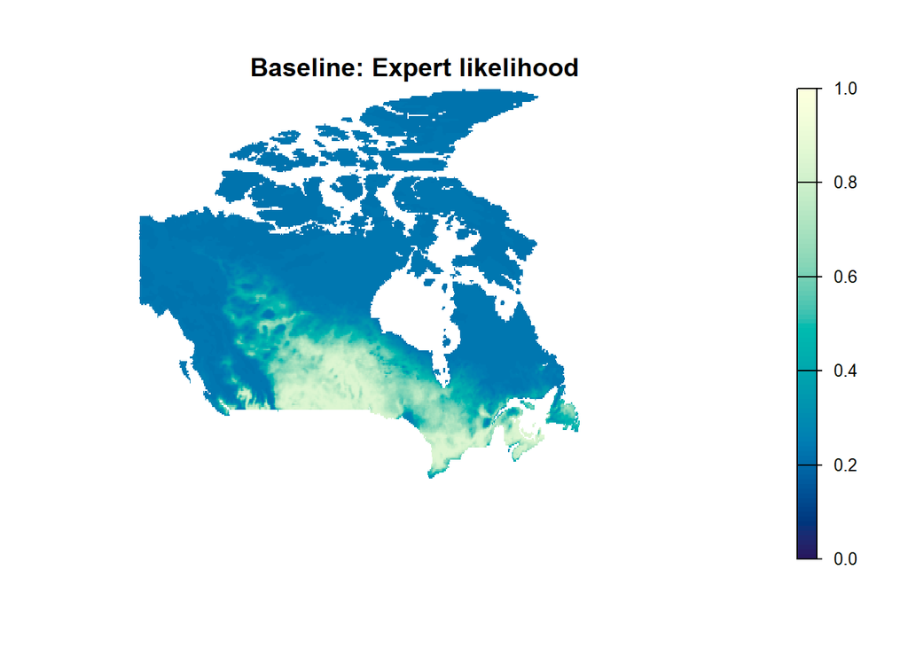

```r
pred_cropped_baseline <- make_pred_raster(preds_baseline, env[[1]], valid_idx)
pred_cropped_weighted <- make_pred_raster(preds_weighted, env[[1]], valid_idx)

pred_prj_baseline <- project(pred_cropped_baseline, map_epsg)
pred_prj_weighted <- project(pred_cropped_weighted, map_epsg)

plot(pred_prj_baseline,
     main  = "Baseline: Expert likelihood",
     col   = hcl.colors(100, "YlGnBu"), range = c(0, 1),
     axes  = FALSE, box = FALSE)
```

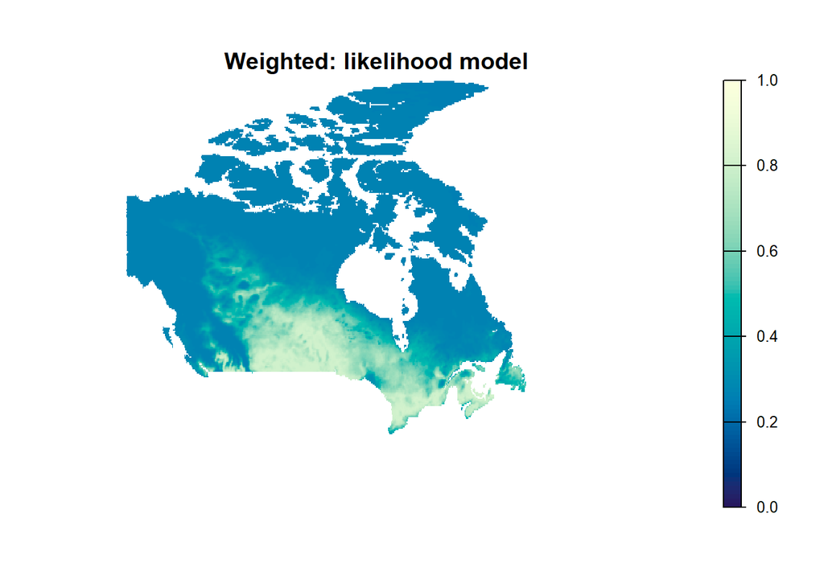

```r
plot(pred_prj_weighted,
     main  = "Weighted: likelihood model",
     col   = hcl.colors(100, "YlGnBu"), range = c(0, 1),
     axes  = FALSE, box = FALSE)
```

# 10. Posterior uncertainty maps (Step 1: expert only)

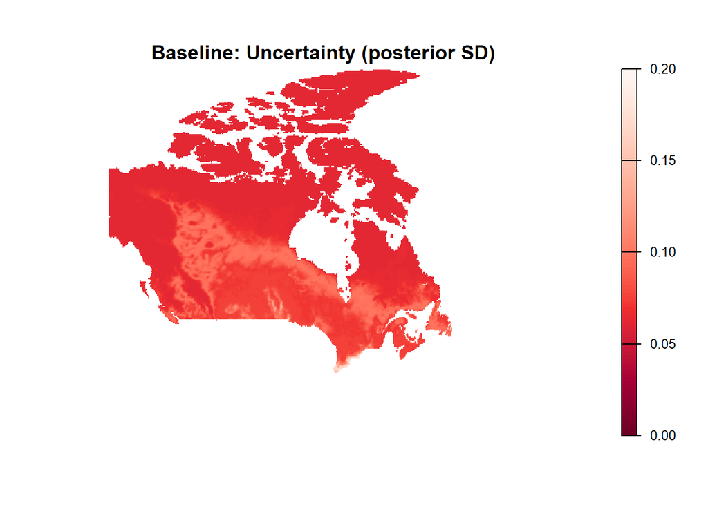

```r
# --- Posterior SD maps ---

sd_cropped_baseline <- make_pred_raster(sd_baseline, env[[1]], valid_idx)
sd_cropped_weighted <- make_pred_raster(sd_weighted, env[[1]], valid_idx)

sd_prj_baseline <- project(sd_cropped_baseline, map_epsg)
sd_prj_weighted <- project(sd_cropped_weighted, map_epsg)

plot(sd_prj_baseline,
     main = "Baseline: Uncertainty (posterior SD)",
     col  = hcl.colors(100, "Reds"), range = c(0, 0.2),axes = FALSE, box = FALSE)
```

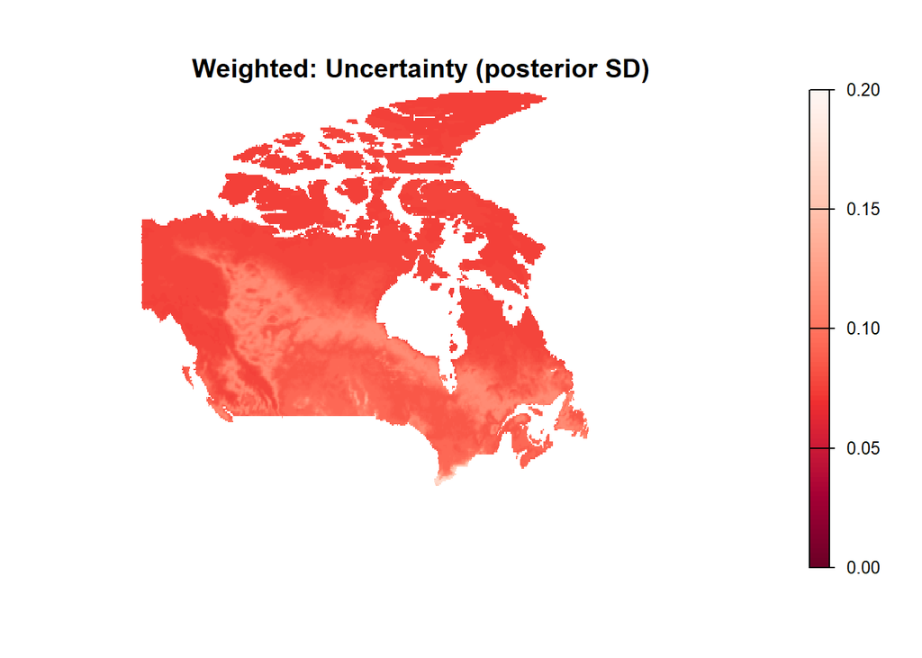

```r
plot(sd_prj_weighted,
     main = "Weighted: Uncertainty (posterior SD)",
     col  = hcl.colors(100, "Reds"), range = c(0, 0.2),axes = FALSE, box = FALSE)
```

# 11. Step 2: Extracting Stan posteriors as INLA priors

```r
# Extract mean and SD from Stan posterior to use as INLA priors.
# Switch `fit_for_inla` to `fit` (baseline) to use base model
fit_for_inla <- fit_weighted   #Weighted likelihood

stan_fixed <- summary(fit_for_inla, pars = c("alpha", "beta1", "beta2"),
                      probs = c(0.025, 0.5, 0.975))$summary

prior_alpha_mean  <- stan_fixed["alpha",  "mean"]
prior_alpha_sd    <- stan_fixed["alpha",  "sd"]

prior_beta1_mean  <- stan_fixed["beta1",  "mean"]
prior_beta1_sd    <- stan_fixed["beta1",  "sd"]

prior_beta2_mean  <- stan_fixed["beta2",  "mean"]
prior_beta2_sd    <- stan_fixed["beta2",  "sd"]
```

This chunk implements the **Bayesian updating** step. The marginal posterior from the expert only Stan model is summarized to a Gaussian approximation, mean and SD for each of the three fixed effects ($\alpha$, $\beta_1$, $\beta_2$), and then used as the prior distribution for the corresponding parameter in the INLA model.

```r
# Convert SD to precision
prec_alpha <- 1 / prior_alpha_sd^2
prec_beta1 <- 1 / prior_beta1_sd^2
prec_beta2 <- 1 / prior_beta2_sd^2

# Build a INLA format priors from Stan posteriors
prior_alpha <- list(prior = "gaussian",
                    param = c(prior_alpha_mean, prec_alpha))

prior_beta1 <- list(prior = "gaussian",
                    param = c(prior_beta1_mean, prec_beta1))

prior_beta2 <- list(prior = "gaussian",
                    param = c(prior_beta2_mean, prec_beta2))
```

R-INLA parameterises Gaussian priors by their **precision** $\tau = 1/\sigma^2$ rather than their standard deviation. The conversion is:

$$\tau_k =
\frac{1}{\sigma_k^2}$$

where $\sigma_k$ is the posterior SD extracted from Stan. Each prior is a named list `list(prior = "gaussian", param = c(mean, precision))`.

# 12. Occurrence data preparation for INLA

```r
monarch_occ <- monarch_sf |>
  mutate(y = monarch_sf$presenc,
         temp = terra::extract(env$temp, vect(monarch_sf))[,2],
         prec = terra::extract(env$prec, vect(monarch_sf))[,2]) |>
  select(c("y","temp","prec"))

head(monarch_occ, 5)
```

```
#> Simple feature collection with 5 features and 3 fields
#> Geometry type: POINT
#> Dimension:     XY
#> Bounding box:  xmin: -3407615 ymin: 25048.92 xmax: -372562.5 ymax: 1910103
#> Projected CRS: NAD83(CSRS)v2 / Quebec Lambert
#>   y      temp       prec                   geometry
#> 1 0 0.3517931 -0.4071499   POINT (-3013170 1803475)
#> 2 0 1.3375935 -1.7895026   POINT (-3407615 1838594)
#> 3 1 1.5483783  1.2980865 POINT (-697865.3 25048.92)
#> 4 1 1.3749465  3.1693399 POINT (-372562.5 234855.6)
#> 5 0 1.0994963 -1.2477435   POINT (-3293597 1910103)
```

The monarch occurrence dataset (`monarch_sf`) is supplement with standardized covariate values extracted at each occurrence point from the `env` stack. The response variable `y` is taken from the `presenc` field. This creates the dataset used in Step 2 to update the expert informed priors with occurrence records from biodiversity databases.

```r
inla_df <- data.frame(
  y  = as.integer(monarch_occ$y),
  x1 = monarch_occ$temp,
  x2 = monarch_occ$prec
)
```

A plain data frame with columns `y`, `x1`, `x2` is created for use inside the INLA stack, which requires non spatial tabular objects.

# 13. SPDE mesh and spatial random effect

```r
# Convert points to SPDE mesh for spatial autocorrelation
coords <- as.matrix(sf::st_coordinates(monarch_occ))

pedge1 <- 0.01
edge1 <- min(c(diff(st_bbox(study_area)[c(1,3)])*pedge1,diff(st_bbox(study_area)[c(2,4)])*pedge1))


mesh <- inla.mesh.2d(loc.domain = NULL,
                     max.edge = c(edge1,edge1*3),
                     min.angle = 21,
                     cutoff = edge1/1,
                     offset = c(edge1,edge1*3),
                     boundary = study_area,
                     crs = st_crs(study_area))


spde <- inla.spde2.pcmatern(
  mesh  = mesh,
  prior.range = c(10, 0.05),
  prior.sigma = c(1, 0.05)
)
iset  <- inla.spde.make.index("s", n.spde = spde$n.spde)
A_est <- inla.spde.make.A(mesh, loc = coords)

stack_est <- inla.stack(
  data    = list(y = inla_df$y),
  A       = list(A_est, 1),
  effects = list(iset,
                 data.frame(intercept = 1,
                            x1 = inla_df$x1,
                            x2 = inla_df$x2)),
  tag     = "est"
)

formula <- y ~ -1 + intercept + x1 + x2 + f(s, model = spde)
```

The spatial random effect accounts for residual spatial autocorrelation in occurrence records, clustering that is not explained by the envionmental layers.

**Mesh** `inla.mesh.2d()` builds a constrained Delaunay triangulation over the study area. The inner maximum edge length is 1 % of the shorter bounding box dimension (`edge1`); the outer buffer uses edges up to three times larger to avoid boundary effects. `min.angle = 21` prevents poorly shaped triangles that degrade numerical precision.

**Full model** The INLA model for observation $n$ is:

$$y_n \sim \text{Bernoulli}(p_n)$$
$$\text{logit}(p_n) = \alpha + \beta_k x_{kn}
+ Z(\mathbf{s}_n)$$

The formula `y ~ -1 + intercept + x1 + x2 + f(s, model = spde)` uses an explicit intercept column (the `-1` suppresses the automatic intercept) so that the `control.fixed` prior can be applied to it by name.

# 14. Prediction with INLA

```r
coords_pred <- as.matrix(env_valid[, c("x", "y")])

# Projector matrix for prediction locations
A_pred <- inla.spde.make.A(mesh, loc = coords_pred)

stack_pred <- inla.stack(
  data    = list(y = NA),
  A       = list(A_pred, 1),
  effects = list(
    iset,
    data.frame(intercept = 1,
               x1 = env_valid$temp,
               x2 = env_valid$prec)
  ),
  tag = "pred"
)

# Join estimation + prediction stacks
stack_full <- inla.stack(stack_est, stack_pred)

# Refit on full stack
fit_inla_full <- inla(
  formula,
  family = "binomial",
  data   = inla.stack.data(stack_full),

  control.fixed = list(
    mean = list(intercept = prior_alpha_mean,
                x1        = prior_beta1_mean,
                x2        = prior_beta2_mean),
    prec = list(intercept = prec_alpha,
                x1        = prec_beta1,
                x2        = prec_beta2)
  ),

  control.predictor = list(
    A       = inla.stack.A(stack_full),
    compute = TRUE,
    link    = 1
  ),

  control.compute = list(dic = TRUE, waic = TRUE, config = TRUE)
)

# Extract predictions for pred stack only
idx_pred   <- inla.stack.index(stack_full, tag = "pred")$data

pred_mean  <- fit_inla_full$summary.fitted.values[idx_pred, "mean"]
pred_sd    <- fit_inla_full$summary.fitted.values[idx_pred, "sd"]
```

To generate a prediction map without refitting, a second INLA stack (`stack_pred`) is created over all valid raster cells. Setting `y = NA` for the prediction rows tells INLA to compute the posterior predictive distribution at those locations but not use them in the likelihood. The estimation and prediction stacks are then joined into `stack_full` and a single `inla()` call fits the model and simultaneously computes predictions.

`control.fixed` passes the Stan derived Gaussian priors to INLA as `(mean, precision)` pairs for each fixed effect. With `link = 1` and `compute = TRUE`, `summary.fitted.values` returns the posterior mean and SD of $p_n$ (on the probability scale, after applying the logit link inverse) for each row in the full stack. The prediction rows are extracted by their tag index.

`control.compute` requests DIC and WAIC for model comparison and `config = TRUE` for access to the internal GMRF configuration (needed for posterior sampling if required later).

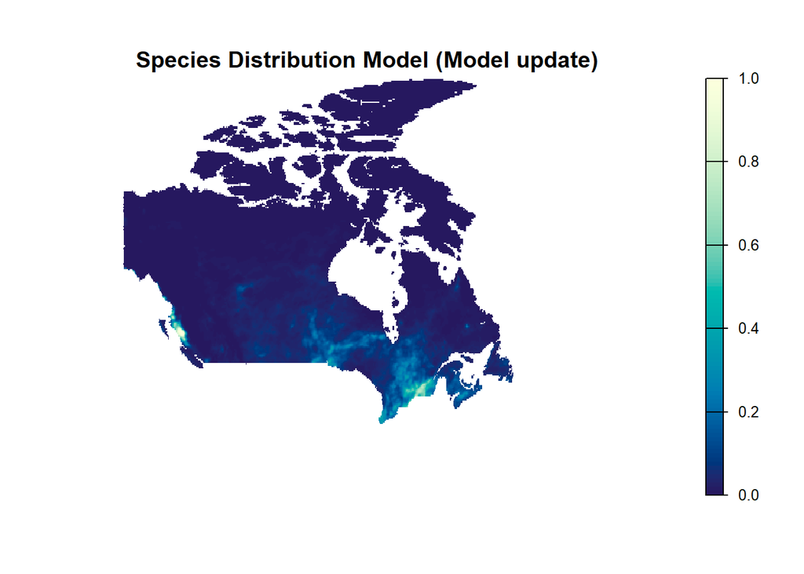

```r
pred_raster <- rast(env$temp)
values(pred_raster) <- NA
pred_raster[valid_idx] <- pred_mean

sd_raster <- rast(env$temp)
values(sd_raster) <- NA
sd_raster[valid_idx] <- pred_sd

non_na_extent <- ext(trim(pred_raster))
pred_cropped <- crop(pred_raster, non_na_extent)
pred_prj <- project(pred_cropped, map_epsg)

plot(pred_prj,
     main = "Species Distribution Model (Model update)",
     col  = hcl.colors(100, "YlGnBu"),
     range = c(0, 1),
     axes   = FALSE,
     box    = FALSE)
```

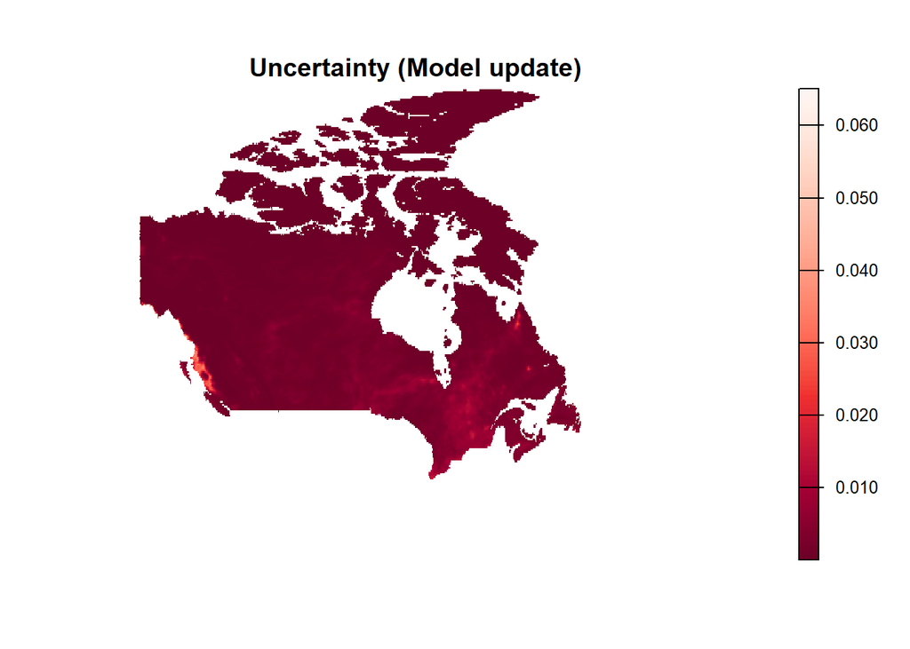

```r
non_na_extent <- ext(trim(sd_raster))
sd_cropped <- crop(sd_raster, non_na_extent)
sd_prj <- project(sd_cropped, map_epsg)

plot(sd_prj,
     main = "Uncertainty (Model update)",
     col  = hcl.colors(100, "Reds"),
     axes   = FALSE,
     box    = FALSE)
```

The flat prediction and SD vectors are inserted back into rasters using the same `valid_idx` mask and then cropped to the non NA extent. These maps represent the **updated** species distribution model: the expert knowledge from Step 1 has been used as informative priors, and the model has been updated with the larger monarch occurrence dataset. The uncertainty map integrates both fixed-effect parameter uncertainty and spatial random effect uncertainty.

# 15. Non informative priors (baseline comparison)

## INLA model: non informed priors

```r
prior.beta <- list(prec = list(default = 1/(1)^2, Intercept = 1/(20)^2),
                   mean = list(default = 0, Intercept = 0))
```

```r
fit_inla_full <- inla(
  formula,
  family = "binomial",
  data   = inla.stack.data(stack_full),
  control.fixed = prior.beta,
  control.predictor = list(
    A       = inla.stack.A(stack_full),
    compute = TRUE,
    link    = 1
  ),

  control.compute = list(dic = TRUE, waic = TRUE, config = TRUE)
)

# Extract predictions for pred stack only
idx_pred   <- inla.stack.index(stack_full, tag = "pred")$data

pred_mean  <- fit_inla_full$summary.fitted.values[idx_pred, "mean"]
pred_sd    <- fit_inla_full$summary.fitted.values[idx_pred, "sd"]
```

The same formula and full stack are used as in the expert informed model, but `control.fixed` is replaced with the non informative `prior.beta` list. All other settings are identical so that differences in the output maps can be attributed solely to the choice of prior.

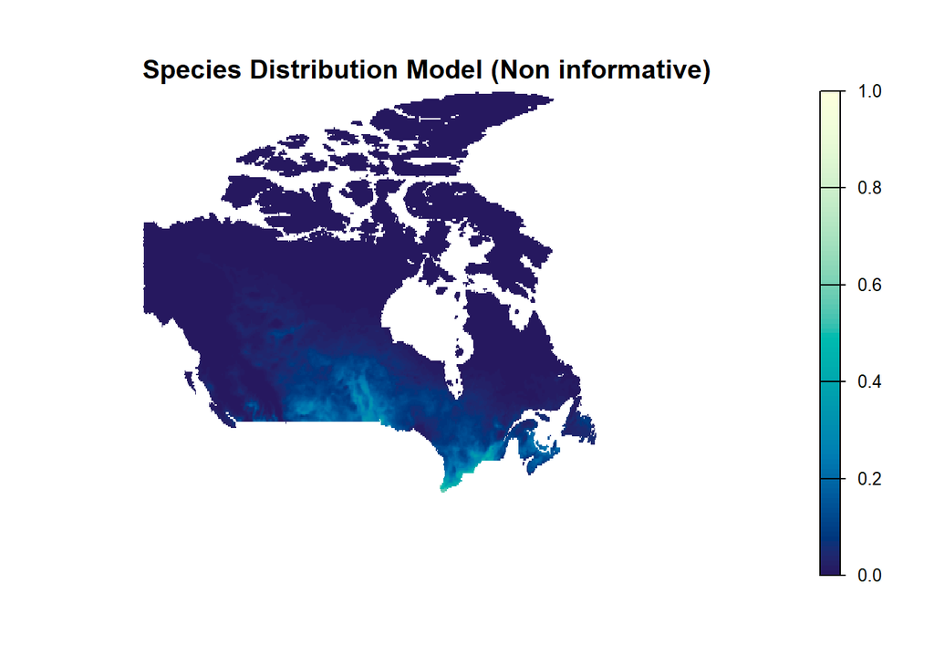

```r
pred_raster <- rast(env$temp)
values(pred_raster) <- NA
pred_raster[valid_idx] <- pred_mean

sd_raster <- rast(env$temp)
values(sd_raster) <- NA
sd_raster[valid_idx] <- pred_sd

non_na_extent <- ext(trim(pred_raster))
pred_cropped <- crop(pred_raster, non_na_extent)
pred_prj <- project(pred_cropped, map_epsg)

plot(pred_prj,
     main = "Species Distribution Model (Non informative)",
     col  = hcl.colors(100, "YlGnBu"),
     range = c(0, 1),
     axes   = FALSE,
     box    = FALSE)
```

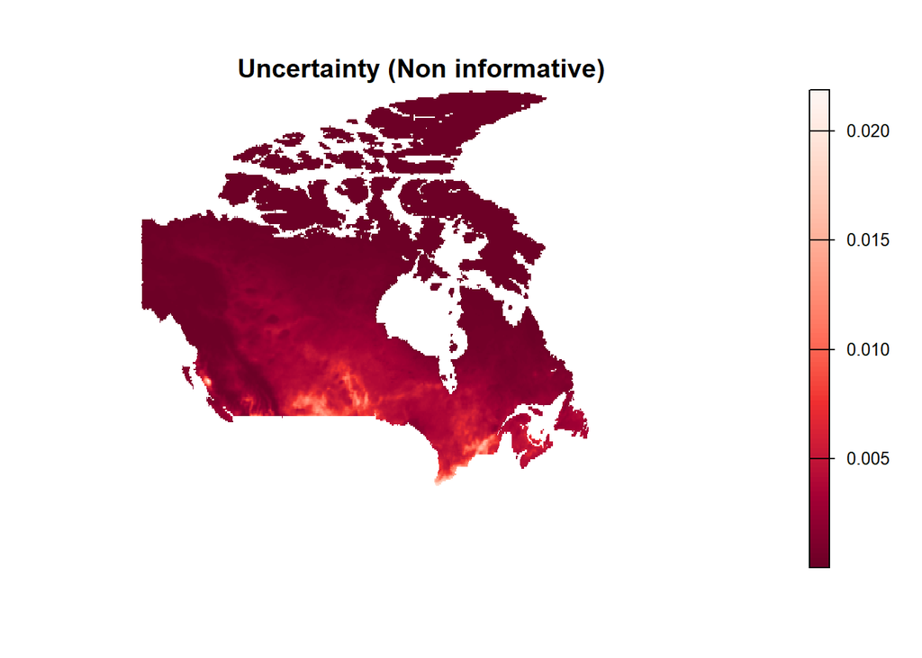

```r
non_na_extent <- ext(trim(sd_raster))
sd_cropped <- crop(sd_raster, non_na_extent)
sd_prj <- project(sd_cropped, map_epsg)

plot(sd_prj,
     main = "Uncertainty (Non informative)",
     col  = hcl.colors(100, "Reds"),
     axes   = FALSE,
     box    = FALSE)
```